# Preferensi Genre Film Berdasarkan Segmentasi Pengeluaran Pelanggan

Apakah pelanggan High-Value memiliki selera genre yang berbeda? — Studi Kasus Database Sakila

Himmatus Sa’adah — M0724012 — SIM G

26 May 2026

Ukuran teks 15px

# 1 Pendahuluan

## 1.1 Deskripsi Dataset

**Database Sakila** adalah contoh database relasional yang dikembangkan oleh MySQL untuk keperluan pembelajaran. Database ini mensimulasikan sistem manajemen penyewaan film (*DVD rental store*) dan terdiri dari **16 tabel** yang saling berelasi, mencakup data pelanggan, film, kategori genre, inventaris, transaksi sewa, hingga pembayaran.

## 1.2 Rumusan Insight Utama

**Pertanyaan Utama:**

> *Apakah pelanggan dengan total pengeluaran tinggi (High-Value) memiliki preferensi genre film yang berbeda secara signifikan dibandingkan pelanggan dengan pengeluaran rendah (Low-Value)?*

Analisis ini bertujuan untuk:

1. **Segmentasi Pelanggan** — Membagi pelanggan menjadi dua segmen (High-Value & Low-Value) berdasarkan median total spending.
2. **Pola Genre** — Mengidentifikasi genre film yang paling banyak disewa di tiap segmen.
3. **Perbandingan Visual** — Melihat perbedaan proporsi genre antar segmen melalui berbagai visualisasi.
4. **Validasi Statistik** — Mengonfirmasi signifikansi perbedaan preferensi genre dengan uji Chi-Square.
5. **Rekomendasi Bisnis** — Menyusun strategi personalisasi berdasarkan temuan.

# 2 Persiapan Data

## 2.1 Memuat Library

```r
library(RMySQL)
library(dplyr)
library(ggplot2)
library(scales)
library(knitr)
library(kableExtra)
library(tidyr)
library(tibble)
library(RColorBrewer)
library(lubridate)
```

## 2.2 Koneksi ke Database Sakila

```r
con <- dbConnect(
  RMySQL::MySQL(),
  dbname   = "sakila",
  host     = "localhost",
  port     = 3306,
  user     = "root",
  password = "himmatyasnida"
)
```

## 2.3 Pengambilan Data

Dua query utama digunakan: (1) total pengeluaran per pelanggan untuk keperluan segmentasi, dan (2) frekuensi sewa per genre per pelanggan untuk analisis preferensi.

```r
# Query 1: Profil pengeluaran per pelanggan
df_spending <- dbGetQuery(con, "
  SELECT
    c.customer_id,
    CONCAT(c.first_name, ' ', c.last_name) AS customer_name,
    SUM(p.amount)      AS total_spending,
    COUNT(r.rental_id) AS total_rental
  FROM customer c
  JOIN payment  p ON c.customer_id = p.customer_id
  JOIN rental   r ON p.rental_id   = r.rental_id
  GROUP BY c.customer_id, customer_name
")

# Query 2: Frekuensi sewa per genre per pelanggan
df_genre <- dbGetQuery(con, "
  SELECT
    c.customer_id,
    cat.name           AS genre,
    COUNT(r.rental_id) AS rental_count
  FROM customer      c
  JOIN rental        r   ON c.customer_id  = r.customer_id
  JOIN inventory     i   ON r.inventory_id = i.inventory_id
  JOIN film          f   ON i.film_id      = f.film_id
  JOIN film_category fc  ON f.film_id      = fc.film_id
  JOIN category      cat ON fc.category_id = cat.category_id
  GROUP BY c.customer_id, cat.name
")
```

# 3 Analisis 1 — Segmentasi Pelanggan Berdasarkan Total Pengeluaran

## 3.1 Konsep & Metodologi

Pelanggan dibagi menjadi dua segmen menggunakan **nilai median** total pengeluaran sebagai ambang batas. Penggunaan median (bukan rata-rata) bertujuan agar segmentasi tidak terpengaruh outlier.

| Segmen | Kriteria |
| --- | --- |
| **High-Value** | Total spending ≥ median |
| **Low-Value** | Total spending < median |

```r
median_val <- median(df_spending$total_spending)

df_spending <- df_spending %>%
  mutate(segment = ifelse(total_spending >= median_val,
                          "High-Value", "Low-Value"))

seg_summary <- df_spending %>%
  group_by(segment) %>%
  summarise(
    n_pelanggan     = n(),
    rata_spending   = round(mean(total_spending), 2),
    median_spending = round(median(total_spending), 2),
    min_spending    = round(min(total_spending), 2),
    max_spending    = round(max(total_spending), 2),
    rata_rental     = round(mean(total_rental), 1),
    .groups = "drop"
  ) %>%
  arrange(desc(rata_spending))
```

## 3.2 Tabel Ringkasan Segmen

```r
seg_summary %>%
  kable(
    col.names = c(
      "Segmen",
      "Jml. Pelanggan",
      "Rata-rata",
      "Median",
      "Minimum",
      "Maksimum",
      "Rata-rata Rental"
    ),
    caption = "Tabel 1. Ringkasan Statistik Segmen Pelanggan",
    format = "html",
    escape = FALSE,
    align = "c"
  ) %>%
  kable_styling(
    bootstrap_options = c("striped", "hover", "condensed"),
    full_width = TRUE,
    position = "center"
  ) %>%
  row_spec(0, bold = TRUE, background = "#5C3A1E", color = "white") %>%
  row_spec(1, bold = TRUE, background = "#D8EDCA") %>%
  row_spec(2, background = "#F5DDD3")
```

Tabel 1. Ringkasan Statistik Segmen Pelanggan

| Segmen | Jml. Pelanggan | Rata-rata | Median | Minimum | Maksimum | Rata-rata Rental |
| --- | --- | --- | --- | --- | --- | --- |
| High-Value | 301 | 132.25 | 128.70 | 110.73 | 221.55 | 30.2 |
| Low-Value | 298 | 92.62 | 94.78 | 50.85 | 110.72 | 23.3 |

## 3.3 Distribusi Total Spending

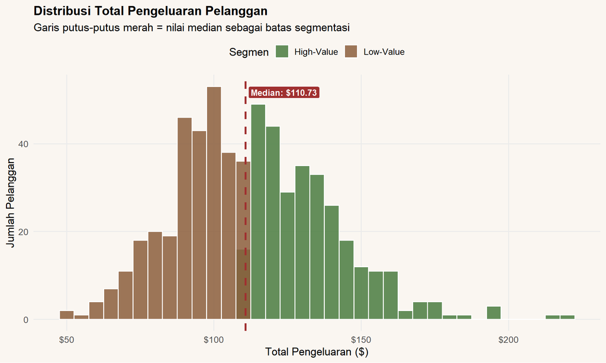

Gambar 1. Distribusi Total Spending per Segmen

```r
ggplot(df_spending, aes(x = total_spending, fill = segment)) +
  geom_histogram(binwidth = 5, color = "white", alpha = 0.85, position = "identity") +
  geom_vline(xintercept = median_val, linetype = "dashed",
             color = "#A03030", linewidth = 1.1) +
  annotate("label", x = median_val + 1, y = Inf,
           label = paste0("Median: $", round(median_val, 2)),
           vjust = 2, hjust = 0, fill = "#A03030", color = "white",
           size = 3.5, fontface = "bold", label.size = 0) +
  scale_fill_manual(values = c("High-Value" = "#4A7C3F", "Low-Value" = "#8B5E3C")) +
  scale_x_continuous(labels = dollar_format()) +
  labs(title    = "Distribusi Total Pengeluaran Pelanggan",
       subtitle = "Garis putus-putus merah = nilai median sebagai batas segmentasi",
       x = "Total Pengeluaran ($)", y = "Jumlah Pelanggan", fill = "Segmen") +
  theme_minimal(base_size = 13) +
  theme(plot.title       = element_text(face = "bold", size = 15),
        plot.background  = element_rect(fill = "#FAF6F1", color = NA),
        panel.background = element_rect(fill = "#FAF6F1", color = NA),
        legend.position  = "top",
        panel.grid.minor = element_blank())
```

**Temuan:** Median pengeluaran pelanggan adalah **$110.73**. Segmen High-Value memiliki rata-rata pengeluaran lebih tinggi dengan distribusi yang lebih menyebar ke kanan.

# 4 Analisis 2 — Top 10 Genre per Segmen

## 4.1 Konsep & Metodologi

Setelah segmen terbentuk, data genre digabungkan untuk menghitung **proporsi penyewaan per genre** di tiap segmen. Proporsi (%) digunakan — bukan nilai absolut — agar perbandingan adil meski jumlah pelanggan berbeda.

```r
df_merged <- df_genre %>%
  left_join(df_spending %>% select(customer_id, segment),
            by = "customer_id")

df_genre_seg <- df_merged %>%
  group_by(segment, genre) %>%
  summarise(total_rental = sum(rental_count), .groups = "drop") %>%
  group_by(segment) %>%
  mutate(pct = total_rental / sum(total_rental) * 100) %>%
  ungroup()
```

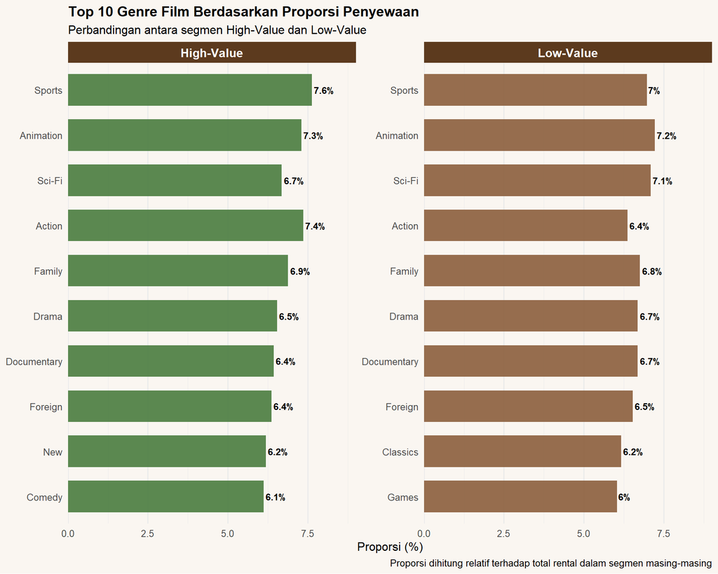

Gambar 2. Top 10 Genre Film per Segmen Pelanggan

```r
top10 <- df_genre_seg %>%
  group_by(segment) %>%
  slice_max(order_by = pct, n = 10) %>%
  ungroup()

ggplot(top10, aes(x = reorder(genre, pct), y = pct, fill = segment)) +
  geom_col(show.legend = FALSE, alpha = 0.9, width = 0.7) +
  geom_text(aes(label = paste0(round(pct, 1), "%")),
            hjust = -0.1, size = 3.3, fontface = "bold") +
  coord_flip() +
  facet_wrap(~segment, scales = "free_y") +
  scale_fill_manual(values = c("High-Value" = "#4A7C3F", "Low-Value" = "#8B5E3C")) +
  scale_y_continuous(expand = expansion(mult = c(0, 0.18))) +
  labs(title    = "Top 10 Genre Film Berdasarkan Proporsi Penyewaan",
       subtitle = "Perbandingan antara segmen High-Value dan Low-Value",
       x = NULL, y = "Proporsi (%)",
       caption  = "Proporsi dihitung relatif terhadap total rental dalam segmen masing-masing") +
  theme_minimal(base_size = 12) +
  theme(plot.title         = element_text(face = "bold", size = 14),
        plot.background    = element_rect(fill = "#FAF6F1", color = NA),
        panel.background   = element_rect(fill = "#FAF6F1", color = NA),
        strip.text         = element_text(face = "bold", size = 12, color = "white"),
        strip.background   = element_rect(fill = "#5C3A1E", color = NA),
        panel.grid.major.y = element_blank())
```

**Temuan:** Distribusi genre antara kedua segmen tampak serupa pada level permukaan, namun terdapat perbedaan proporsi pada beberapa genre tertentu yang akan dieksplor lebih jauh di analisis berikutnya.

# 5 Analisis 3 — Heatmap Proporsi Genre × Segmen

## 5.1 Konsep & Metodologi

Heatmap memungkinkan perbandingan proporsi semua genre sekaligus. Warna lebih gelap menunjukkan proporsi lebih tinggi, memudahkan identifikasi genre yang “dominan” di tiap segmen.

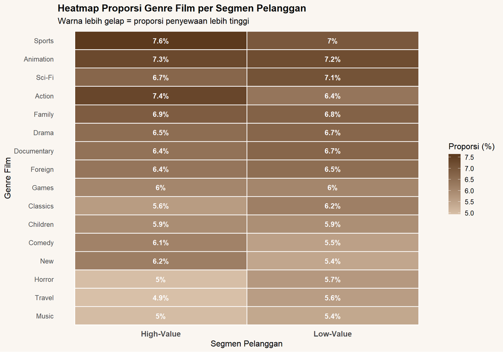

Gambar 3. Heatmap Proporsi Genre per Segmen

```r
ggplot(df_genre_seg,
       aes(x = segment, y = reorder(genre, pct), fill = pct)) +
  geom_tile(color = "white", linewidth = 0.6) +
  geom_text(aes(label = paste0(round(pct, 1), "%")),
            size = 3.5, color = "white", fontface = "bold") +
  scale_fill_gradient(low = "#D8C0A8", high = "#5C3A1E",
                      name = "Proporsi (%)") +
  labs(title    = "Heatmap Proporsi Genre Film per Segmen Pelanggan",
       subtitle = "Warna lebih gelap = proporsi penyewaan lebih tinggi",
       x = "Segmen Pelanggan", y = "Genre Film") +
  theme_minimal(base_size = 12) +
  theme(plot.title   = element_text(face = "bold", size = 14),
        plot.background  = element_rect(fill = "#FAF6F1", color = NA),
        panel.background = element_rect(fill = "#FAF6F1", color = NA),
        axis.text.x  = element_text(face = "bold", size = 11),
        panel.grid   = element_blank())
```

**Temuan:** Heatmap memperlihatkan pola warna yang berbeda antara dua segmen untuk genre tertentu, mengindikasikan adanya perbedaan preferensi yang layak dikonfirmasi secara statistik.

# 6 Analisis 4 — Selisih Proporsi Genre Antar Segmen

## 6.1 Konsep & Metodologi

*Diverging bar chart* menampilkan selisih proporsi genre secara langsung:

$$\text{Selisih} =
\text{Proporsi}_{\text{High-Value}} -
\text{Proporsi}_{\text{Low-Value}}$$

- **Batang hijau (positif)** → genre lebih dominan di High-Value
- **Batang cokelat (negatif)** → genre lebih dominan di Low-Value

```r
df_wide <- df_genre_seg %>%
  select(segment, genre, pct) %>%
  pivot_wider(names_from  = segment,
              values_from = pct,
              values_fill = 0) %>%
  mutate(
    selisih = `High-Value` - `Low-Value`,
    dominan = ifelse(selisih > 0,
                     "Lebih tinggi di High-Value",
                     "Lebih tinggi di Low-Value")
  )
```

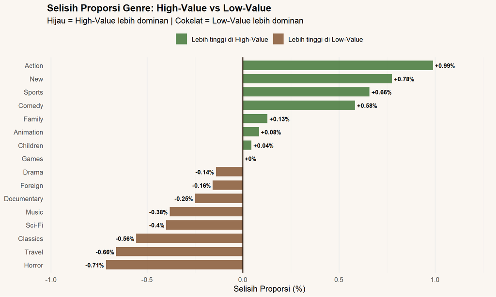

Gambar 4. Diverging Bar Chart: Selisih Proporsi Genre

```r
ggplot(df_wide,
       aes(x = reorder(genre, selisih), y = selisih, fill = dominan)) +
  geom_col(alpha = 0.88, width = 0.7) +
  geom_hline(yintercept = 0, color = "#2C1A0E", linewidth = 0.8) +
  geom_text(
    aes(label = paste0(ifelse(selisih > 0, "+", ""), round(selisih, 2), "%"),
        hjust = ifelse(selisih > 0, -0.1, 1.1)),
    size = 3.2, fontface = "bold"
  ) +
  coord_flip() +
  scale_fill_manual(values = c("Lebih tinggi di High-Value" = "#4A7C3F",
                               "Lebih tinggi di Low-Value"  = "#8B5E3C")) +
  scale_y_continuous(expand = expansion(mult = c(0.18, 0.18))) +
  labs(title    = "Selisih Proporsi Genre: High-Value vs Low-Value",
       subtitle = "Hijau = High-Value lebih dominan | Cokelat = Low-Value lebih dominan",
       x = NULL, y = "Selisih Proporsi (%)", fill = NULL) +
  theme_minimal(base_size = 12) +
  theme(plot.title         = element_text(face = "bold", size = 14),
        plot.background    = element_rect(fill = "#FAF6F1", color = NA),
        panel.background   = element_rect(fill = "#FAF6F1", color = NA),
        legend.position    = "top",
        panel.grid.major.y = element_blank())
```

## 6.2 Tabel Perbandingan Detail

```r
df_wide_disp <- df_wide %>%
  arrange(desc(abs(selisih))) %>%
  mutate(across(c(`High-Value`, `Low-Value`, selisih), ~round(., 2)))

df_wide_disp %>%
  kable(
    col.names = c("Genre", "High-Value (%)", "Low-Value (%)",
                  "Selisih (%)", "Dominan"),
    caption   = "Tabel 2. Perbandingan Proporsi Genre (Diurutkan Selisih Terbesar)",
    escape    = TRUE
  ) %>%
  kable_styling(bootstrap_options = c("striped","hover","condensed"),
                full_width = TRUE) %>%
  row_spec(0, bold = TRUE, background = "#5C3A1E", color = "white") %>%
  column_spec(5,
              background = ifelse(df_wide_disp$selisih > 0, "#D8EDCA", "#F5DDD3"),
              bold = TRUE)
```

Tabel 2. Perbandingan Proporsi Genre (Diurutkan Selisih Terbesar)

| Genre | High-Value (%) | Low-Value (%) | Selisih (%) | Dominan |
| --- | --- | --- | --- | --- |
| Action | 7.36 | 6.37 | 0.99 | Lebih tinggi di High-Value |
| New | 6.19 | 5.42 | 0.78 | Lebih tinggi di High-Value |
| Horror | 4.96 | 5.68 | -0.71 | Lebih tinggi di Low-Value |
| Travel | 4.93 | 5.59 | -0.66 | Lebih tinggi di Low-Value |
| Sports | 7.63 | 6.98 | 0.66 | Lebih tinggi di High-Value |
| Comedy | 6.12 | 5.53 | 0.58 | Lebih tinggi di High-Value |
| Classics | 5.61 | 6.17 | -0.56 | Lebih tinggi di Low-Value |
| Sci-Fi | 6.69 | 7.09 | -0.40 | Lebih tinggi di Low-Value |
| Music | 5.01 | 5.39 | -0.38 | Lebih tinggi di Low-Value |
| Documentary | 6.44 | 6.69 | -0.25 | Lebih tinggi di Low-Value |
| Foreign | 6.37 | 6.53 | -0.16 | Lebih tinggi di Low-Value |
| Drama | 6.55 | 6.69 | -0.14 | Lebih tinggi di Low-Value |
| Family | 6.89 | 6.76 | 0.13 | Lebih tinggi di High-Value |
| Animation | 7.30 | 7.22 | 0.08 | Lebih tinggi di High-Value |
| Children | 5.91 | 5.87 | 0.04 | Lebih tinggi di High-Value |
| Games | 6.04 | 6.04 | 0.00 | Lebih tinggi di High-Value |

**Temuan:** Genre dengan selisih proporsi terbesar (posisi paling atas tabel) adalah kandidat utama untuk strategi personalisasi rekomendasi film.

# 7 Analisis 5 — Uji Chi-Square: Validasi Statistik

## 7.1 Konsep & Metodologi

Untuk mengonfirmasi bahwa perbedaan preferensi genre antar segmen **bukan sekadar kebetulan**, dilakukan uji independensi Chi-Square ($\chi^2$).

**Hipotesis:**

$$H_0: \text{Tidak ada hubungan antara
segmen pengeluaran dan preferensi genre}$$

$$H_1: \text{Ada hubungan signifikan
antara segmen pengeluaran dan preferensi genre}$$

**Tingkat signifikansi:** $\alpha = 0{,}05$

```r
contingency_tbl <- df_merged %>%
  group_by(genre, segment) %>%
  summarise(total = sum(rental_count), .groups = "drop") %>%
  pivot_wider(names_from  = segment,
              values_from = total,
              values_fill = 0) %>%
  column_to_rownames("genre") %>%
  as.matrix()

chi_result <- chisq.test(contingency_tbl)
```

## 7.2 Hasil Uji Chi-Square

```r
data.frame(
  Statistik = c("Chi-Square (X²)", "Degrees of Freedom (df)",
                "p-value", "Kesimpulan (α = 0,05)"),
  Nilai     = c(
    round(chi_result$statistic, 4),
    chi_result$parameter,
    format(chi_result$p.value, scientific = TRUE),
    ifelse(chi_result$p.value < 0.05,
           "Tolak H0 — ada perbedaan signifikan",
           "Gagal tolak H0 — tidak cukup bukti")
  )
) %>%
  kable(col.names = c("Statistik", "Nilai"),
        caption   = "Tabel 3. Hasil Uji Chi-Square",
        escape    = TRUE) %>%
  kable_styling(bootstrap_options = c("striped","hover","condensed"),
                full_width = FALSE) %>%
  row_spec(0, bold = TRUE, background = "#5C3A1E", color = "white") %>%
  row_spec(4, bold = TRUE,
           background = ifelse(chi_result$p.value < 0.05, "#D8EDCA", "#F5DDD3"))
```

Tabel 3. Hasil Uji Chi-Square

| Statistik | Nilai |
| --- | --- |
| Chi-Square (X²) | 26.2087 |
| Degrees of Freedom (df) | 15 |
| p-value | 3.588513e-02 |
| Kesimpulan (α = 0,05) | Tolak H0 — ada perbedaan signifikan |

## 7.3 Peta Residual Pearson

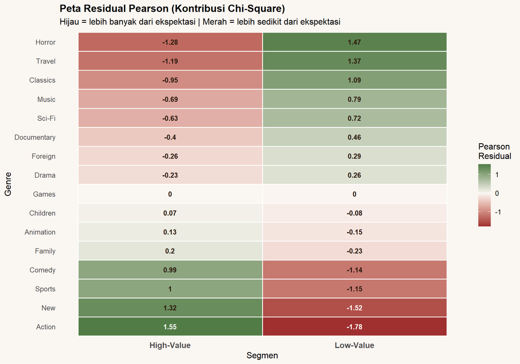

Gambar 5. Peta Residual Pearson (Kontribusi Chi-Square per Sel)

```r
resid_df <- as.data.frame(chi_result$residuals) %>%
  rownames_to_column("genre") %>%
  pivot_longer(-genre, names_to = "segment", values_to = "residual")

ggplot(resid_df,
       aes(x = segment, y = reorder(genre, residual), fill = residual)) +
  geom_tile(color = "white", linewidth = 0.6) +
  geom_text(
    aes(label = round(residual, 2)),
    size = 3.4, fontface = "bold",
    color = ifelse(abs(resid_df$residual) > 1.5, "white", "#2C1A0E")
  ) +
  scale_fill_gradient2(low = "#A03030", mid = "#FAF6F1", high = "#3A6B2F",
                       midpoint = 0, name = "Pearson\nResidual") +
  labs(title    = "Peta Residual Pearson (Kontribusi Chi-Square)",
       subtitle = "Hijau = lebih banyak dari ekspektasi | Merah = lebih sedikit dari ekspektasi",
       x = "Segmen", y = "Genre") +
  theme_minimal(base_size = 12) +
  theme(plot.title       = element_text(face = "bold", size = 14),
        plot.background  = element_rect(fill = "#FAF6F1", color = NA),
        panel.background = element_rect(fill = "#FAF6F1", color = NA),
        axis.text.x      = element_text(face = "bold", size = 11),
        panel.grid       = element_blank())
```

**Temuan — Uji Chi-Square:**

- **Chi-Square** = 26.2087
- **df** = 15
- **p-value** = 3.588513e-02

Karena p-value < 0,05, maka **H₀ ditolak**. Terdapat perbedaan preferensi genre yang signifikan secara statistik antara pelanggan High-Value dan Low-Value.

Peta residual Pearson menunjukkan genre yang paling menyimpang dari ekspektasi — warna **hijau tua** = *over-representation*, warna **merah** = *under-representation* di segmen tersebut.

# 8 Interpretasi & Rekomendasi

## 8.1 Ringkasan Temuan

**1. Segmentasi Pelanggan** Pelanggan terbagi merata berdasarkan median spending ($110.73). Perbedaan rata-rata pengeluaran antar segmen mencerminkan pola konsumsi yang berbeda secara kuantitatif.

**2. Pola Preferensi Genre** Visualisasi top-10 genre dan diverging bar chart mengidentifikasi genre dengan perbedaan proporsi terbesar antar segmen. Genre-genre ini adalah sinyal kuat untuk personalisasi layanan.

**3. Validasi Statistik** Uji Chi-Square mengonfirmasi bahwa perbedaan distribusi genre antar segmen **signifikan secara statistik** (p-value = 3.588513e-02). Peta residual Pearson memperlihatkan genre spesifik yang menjadi pembeda utama.

## 8.2 Rekomendasi Bisnis

**1. Personalisasi Rekomendasi** Gunakan profil genre dominan per segmen sebagai dasar *recommendation engine* — tampilkan genre favorit segmen saat pelanggan mengakses katalog.

**2. Strategi Stok Inventaris** Prioritaskan ketersediaan film pada genre yang *over-represented* di segmen High-Value, karena segmen ini memberikan pendapatan lebih besar per pelanggan.

**3. Promosi Silang** Tawarkan diskon khusus untuk genre yang *under-represented* di High-Value untuk meningkatkan variasi konsumsi pelanggan bernilai tinggi.

**Keterbatasan Analisis:**

- Segmentasi binary (High/Low) dengan median bersifat sederhana. Untuk insight lebih granular, pertimbangkan segmentasi quartile atau K-Means clustering.
- Proporsi genre tidak memperhitungkan ketersediaan judul per genre di inventaris — genre dengan lebih banyak judul otomatis punya peluang lebih besar disewa.
- Analisis bersifat deskriptif–inferensial; tidak menyimpulkan kausalitas antara spending dan preferensi genre.

*Laporan dibuat menggunakan **R Markdown** dengan koneksi langsung ke database Sakila via `RMySQL`. Visualisasi menggunakan `ggplot2`; uji statistik menggunakan fungsi bawaan R.*